# IODS course project

## 4: Exploring these relations

One way to explore these data is to plot the proportion of high alcohol users for different levels of our variables in question (goout, sex, studytime, and famrel).

However, by only looking at the proportion, we’re missing out on some important data: How many students there are in each category. This can tell us the strengt of the different values.

To solve this, we’ll make plots showing both the proportion of high alcohol users for different levels of our variables, but also plot the distribution (histogram) of our variable in question.

To make this process a little cleaner, we’ll make a general function for making this plot (based on the variable in question “var”)

```r
# Set up a general function to make these plots

makeplot <- function(var){
  # Make a table where each row is one value of our explanatory variable...
  # ... and the column "p_high_use" says the proportion of high alcohol users...
  # ... there are in this this group
  tb_alc_grouped <-
    tb_alc %>%
    group_by(!!var) %>%
    summarise(p_high_use=sum(high_use)/n())

  # find the max y value for the histogram we're gong to be plotting,
  # We'll use that as a scaling factor for the second y axis of the plot
  ymax <- tb_alc %>% group_by(!!var) %>% summarise(n=n()) %>% pull(n) %>% max()
  scale = ymax

  # make the plot, drawing both the histogram of our variable in question (x), as well as a line showing the
  # - proportion of high alcohol users in for each value of x
  ggplot()+
    labs(title=glue("Distribution (bars) of {as.character(var)[2]} and the proportion (line) of \n high alcohol users in each category"))+
    geom_histogram(data=tb_alc,aes(x=!!var), stat="count")+
    geom_point(data=tb_alc_grouped,aes(x=!!var, y=p_high_use*scale),col="red",size=3)+
    scale_y_continuous(
      name = "N (bars)", sec.axis = sec_axis(~./(scale/100), name="% High alcohol use (line)")
    )
}
```

Then we can make the plots:

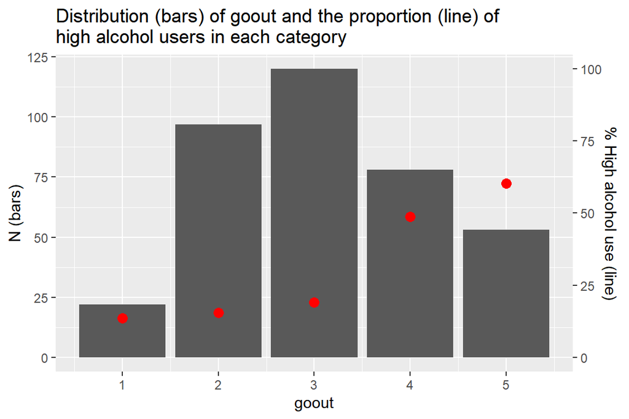

```r
makeplot(quo(goout))
```

This plot seems to go against my initial hypothesis. It seems like there’s a higher proportion of high alcohol users among those who go out a lot. There is quite a bit fewer students going out a lot than those going out a lot (4-5) than those going out less (1-3), but probably not few enough to drive any extreme relationships; also the pattern is quite strong. Based on this graph I’m guessing my hypothesis was not right, but let’s see what the analysis says later.

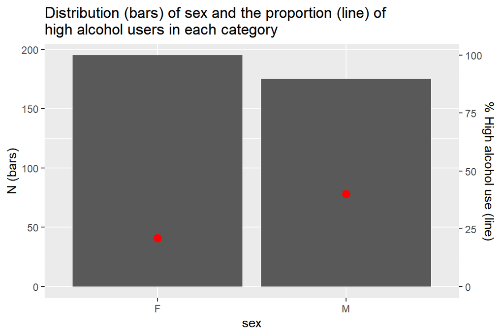

```r
makeplot(quo(sex))
```

This plot seems to be in line with my hypothesis that the number of high alcohol users would be different between the sexes. It looks like there more high alcohol users among the male students than among the female students. There are slightly more female students than male students, but the different is not large.

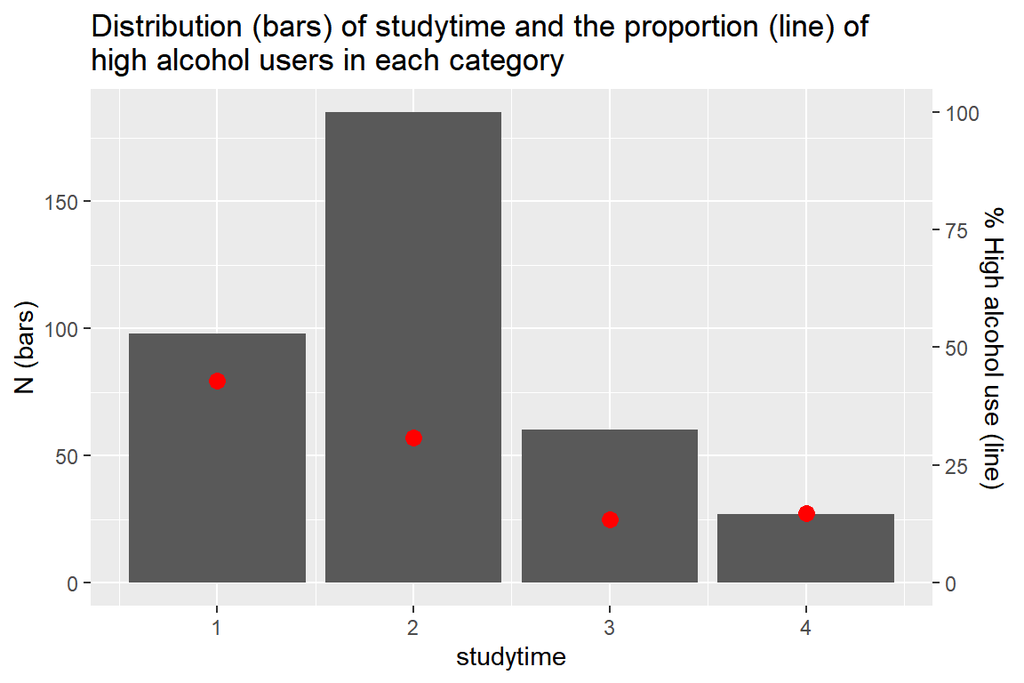

```r
makeplot(quo(studytime))
```

This also seems to go with my hypothesis that students who spend a lot of time studying also have low frequencies of high alcohol use. There is also relatively few students who study a lot.

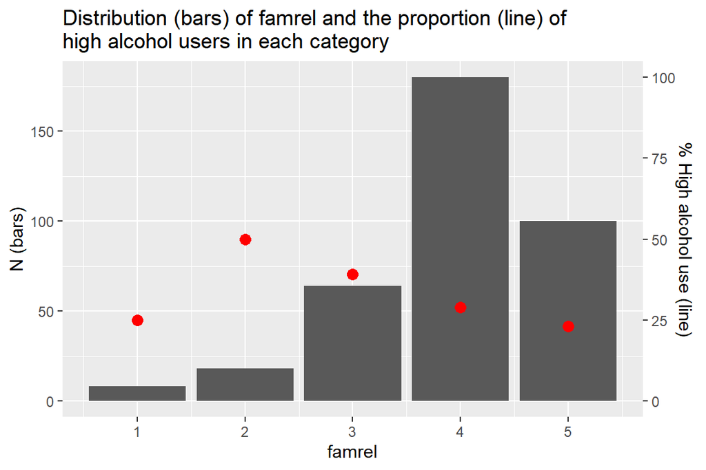

```r
makeplot(quo(famrel))
```

This one is interesting, it seems like students with a poor family relations do have a higher incidence of high alcohol use, except for when the family relations are **really** poor (famrel=1). **However**, note that the sample sizes for Famrel < 3 is also very low, so it is possible that the small sample sizes are driving more extreme (or “random”) values for incidence of high alcohol use. I would therefore be a little sceptical of drawing conclusions from this graph.

## 5: logistc regression

We’ll start by fitting a generalized linear model using our variables and a logit link function (family=“binomial”). Then also printing out the summary of the model

```r
model = glm( high_use ~ goout + sex + studytime + famrel, family="binomial", data=tb_alc)
```

To get a better idea of the parameter estimates and their confidence intervals, we’ll print those out after having done an exponential transformation on them (transforming log odds rations to odds ratios)

```r
exp(confint(model))
```

```
##                  2.5 %    97.5 %
## (Intercept) 0.06545486 1.1622100
## goout       1.73873662 2.8198312
## sexM        1.31841735 3.7630180
## studytime   0.43751933 0.8576353
## famrel      0.49791884 0.8636137
```

```r
summary(model)[12]$coefficients %>% as.data.frame() %>% mutate(Estimate=exp(Estimate), `Pr(>|z|)`=round(`Pr(>|z|)`,5))
```

```
##              Estimate Std. Error   z value Pr(>|z|)
## (Intercept) 0.2816141  0.7312170 -1.733025  0.08309
## goout       2.1974324  0.1230422  6.398534  0.00000
## sexM        2.2165443  0.2669277  2.981891  0.00286
## studytime   0.6179355  0.1710716 -2.813859  0.00490
## famrel      0.6575181  0.1399361 -2.996245  0.00273
```

It seems like all our selected variables associate significantly with high alcohol usage (at $\alpha=0.05$), since the p value for each variable is lower then 0.05

Going through each variable:

**Time spent going out**. This variable is associating positively (opposite of my hypothesis, oh well), so more time spent going out means higher probability of having a high alcohol usage. Specifically, for each point (from 1 to 5, from very low to very high ) on self reported time spent going out, the students have a 2.2 times [95% CI: 1.74-2.82] higher odds of having a high alcohol consumption.

**Sex**. Male-identifying students have a 2.2 times [95% CI: 1.32-3.76] higher odds of having a high alcohol consumption compared to female-identifying students. Male students drink more than female students (supporting my hypothesis that male and female students have different levels of alcohol consumptions)

**Family relationship**. For each point (from 1 to 5, going from very bad to excellent) of self reported family relationship, the students have a 0.66-fold [95% CI: 0.50-0.86] lower odds of having a high alcohol consumption. Better family relationships = less alcohol (as hypothesised)

## 6: Cross tabulation

```r
# Creating the predictions
tb_alc_pred <-
  tb_alc %>%
  mutate(
    probability = predict(model,type="response"),
    prediction = rbinom(n=n(),1,probability)
  )

# Making the cross tabulation
crosstab <- tb_alc_pred %>%
  group_by(high_use) %>%
  summarise(
    n_wrong = sum(high_use!=prediction),
    n_right = sum(high_use==prediction)
  )

# Calculating the percentage wrong predictions
p_wrong = sum( tb_alc_pred$high_use != tb_alc_pred$prediction ) / nrow(tb_alc_pred) * 100
```

| high_use | n_wrong | n_right |
| --- | --- | --- |
| FALSE | 62 | 197 |
| TRUE | 60 | 51 |

We can also plot this:

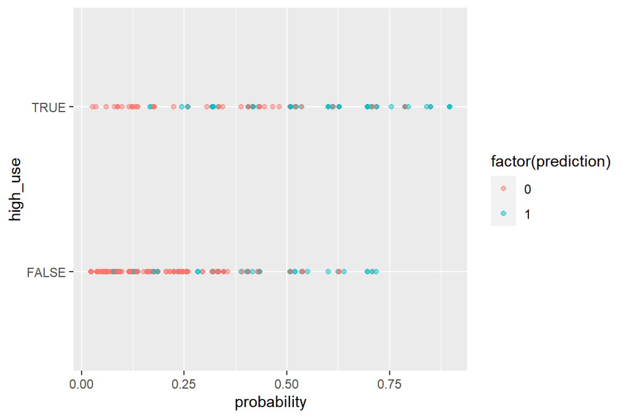

```r
# Plotting the predictions
ggplot(tb_alc_pred)+
  aes(x=probability,y=high_use,col=factor(prediction))+
  geom_point(alpha=0.5)
```

The plot shows each student as one dot; The upper line is those with a high alcohol usage, and the lower line is those witout a high alcohol usage. **Red** points are those predicted to **not** have a high usage, and **blue** points are those predicted to **have** a high usage. The x-axis shows the estimated probability of high usage taken from the model.

As for the comparison with a simple guessing strategy; I found the question unclear and decided not to spend time on it. Leaving this part blank here.

## 7: Cross validation

```r
# Setting up the loss function (same as in the exercise)
loss_func <- function(class, prob) {
  n_wrong <- abs(class - prob) > 0.5
  mean(n_wrong)
}

# Running a 10-fold cross validation
library(boot)
cv <- cv.glm(data = tb_alc, cost = loss_func, glmfit = model, K = 10)
```

Our cross validation tell us that our function had an error of 0.2459459, which is actually better than the one used in the exercise. Looks like we already found a model with a better predictive accuracy. `

# Chapter 4 Boston data

## 2) Load and explore

```r
library(tidyverse)
library(GGally)
library(ggord)

tb_boston <- MASS::Boston
str(tb_boston)
```

```
## 'data.frame':    506 obs. of  14 variables:
##  $ crim   : num  0.00632 0.02731 0.02729 0.03237 0.06905 ...
##  $ zn     : num  18 0 0 0 0 0 12.5 12.5 12.5 12.5 ...
##  $ indus  : num  2.31 7.07 7.07 2.18 2.18 2.18 7.87 7.87 7.87 7.87 ...
##  $ chas   : int  0 0 0 0 0 0 0 0 0 0 ...
##  $ nox    : num  0.538 0.469 0.469 0.458 0.458 0.458 0.524 0.524 0.524 0.524 ...
##  $ rm     : num  6.58 6.42 7.18 7 7.15 ...
##  $ age    : num  65.2 78.9 61.1 45.8 54.2 58.7 66.6 96.1 100 85.9 ...
##  $ dis    : num  4.09 4.97 4.97 6.06 6.06 ...
##  $ rad    : int  1 2 2 3 3 3 5 5 5 5 ...
##  $ tax    : num  296 242 242 222 222 222 311 311 311 311 ...
##  $ ptratio: num  15.3 17.8 17.8 18.7 18.7 18.7 15.2 15.2 15.2 15.2 ...
##  $ black  : num  397 397 393 395 397 ...
##  $ lstat  : num  4.98 9.14 4.03 2.94 5.33 ...
##  $ medv   : num  24 21.6 34.7 33.4 36.2 28.7 22.9 27.1 16.5 18.9 ...
```

In the **Boston** dataset, each row is one town/suburb (total N=506) of the city Boston, Massachutes. The dataset contains various demographic, area-use related, environmental and infrstracture data. [Full description](https://www.rdocumentation.org/packages/MASS/versions/7.3-58.1/topics/Boston). Some examples: - crim: Is the per capita crime rate in this area - nox: The nitrogen oxides concentrations (parts per 10 million) - rad: Index of accessibility to radial highways. - ptratio: Pupil-teacher ratio by town. etc…

## 3 Graphical overview

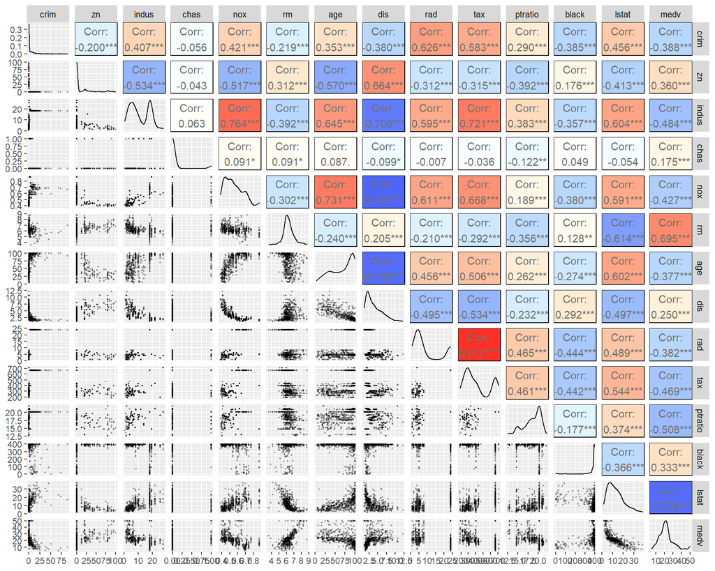

```r
color_correlation <- function(data, mapping, method="p", use="pairwise", ...){
    # Function by user20650 on Stackoverflow (https://stackoverflow.com/a/53685979)
    # grab data
    x <- eval_data_col(data, mapping$x)
    y <- eval_data_col(data, mapping$y)

    # calculate correlation
    corr <- cor(x, y, method=method, use=use)

    # calculate colour based on correlation value
    # Here I have set a correlation of minus one to blue,
    # zero to white, and one to red
    # Change this to suit: possibly extend to add as an argument of `my_fn`
    colFn <- colorRampPalette(c("blue", "white", "red"), interpolate ='spline')
    fill <- colFn(100)[findInterval(corr, seq(-1, 1, length=100))]

    ggally_cor(data = data, mapping = mapping, ...) +
      theme_void() +
      theme(panel.background = element_rect(fill=fill))
  }


ggpairs(
  data = tb_boston,
  upper = list(continuous = color_correlation),
  lower = list(continuous = wrap("points", alpha = 0.3, size=0.3)),
)
```

That’s an overwhelming amount of correlating data! It’s almost easier to describe what’s **not** correlating rather whan what is. I’m guessing that the data here must be a selection of some larger data set where only the most interesting/correlating data has been kept in. We can also see that very few of the variables follow simple normal distributions, often having multiple peacks, or being highle skewed either to the left or to the right.

## 4) standardizing

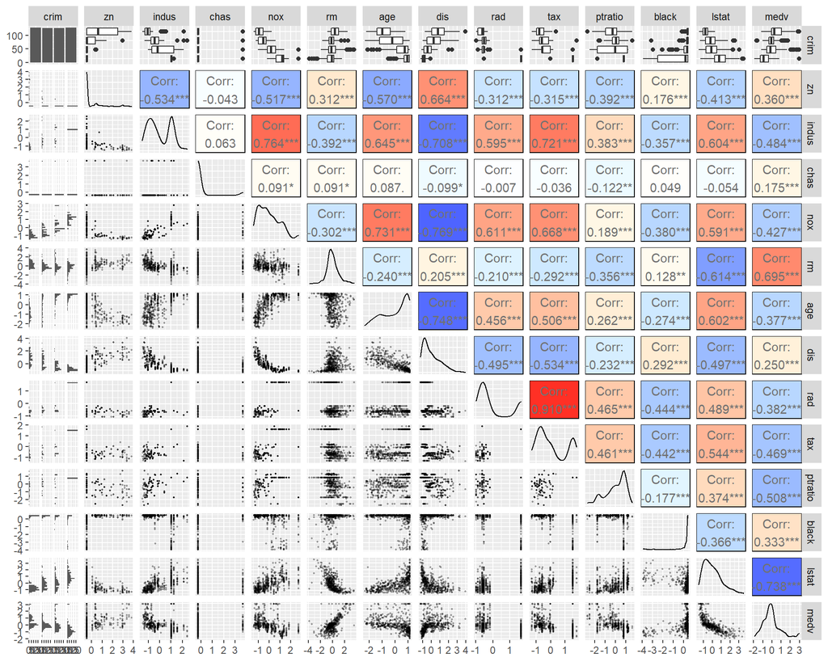

```r
# A function for randomizing the order of rows in a table
randomize_rows <- function(tb){
  return(
   tb %>%
     mutate( order=sample(row_number()) ) %>%
     arrange(order) %>%
     select(-order)
  )
}

# Standardizing all variables,
# Turn crim into a categorical variable, divide by quantiles in ranges of 25%
# - and randomize the order of the rows in the dataset before cutting it of into test- and training sets later
tb_boston_st <- tb_boston %>%
  mutate_all( ~ scale(.)[,1]) %>%
  mutate(
    crim = cut(crim,quantile(crim, probs=c(0,0.25,0.5,0.75,1)),labels=c("low","med_low","med_high","high"),include.lowest=T)
  ) %>%
  randomize_rows()

cutoff_80 = round(nrow(tb_boston_st)*0.8)
tb_boston_st_train = tb_boston_st[1:cutoff_80,]
tb_boston_st_test =  tb_boston_st[(cutoff_80+1):nrow(tb_boston_st),]

ggpairs(
  data = tb_boston_st,
  upper = list(continuous = color_correlation),
  lower = list(continuous = wrap("points", alpha = 0.3, size=0.3)),
)
```

After standardizing all the columns in the dataset, each variable is centered on zero, and its value is expressed in standard deviations. Because of this, it’s not easy to see the changes visually in the figure above; the only place you can really see the change is by looking at the axis values.

## 5) Linear discriminant analysis

```r
lindis <- MASS::lda(crim~.,tb_boston_st_train)

print(lindis)
```

```
## Call:
## lda(crim ~ ., data = tb_boston_st_train)
##
## Prior probabilities of groups:
##       low   med_low  med_high      high
## 0.2444444 0.2518519 0.2592593 0.2444444
##
## Group means:
##                   zn      indus        chas        nox         rm        age
## low       0.89955366 -0.9004765 -0.11325431 -0.8450056  0.4119834 -0.8396612
## med_low  -0.07780557 -0.2787278 -0.04073494 -0.5440910 -0.1425302 -0.3176529
## med_high -0.38760189  0.1834811  0.21512144  0.3470835  0.1381961  0.4056445
## high     -0.48724019  1.0171737 -0.03371693  1.0177215 -0.4775911  0.7833479
##                 dis        rad        tax    ptratio       black       lstat
## low       0.8603080 -0.6906942 -0.7568682 -0.4315681  0.37560621 -0.75155516
## med_low   0.3126487 -0.5573888 -0.4394907 -0.1080697  0.31326621 -0.12562318
## med_high -0.3551259 -0.4349821 -0.3105661 -0.2156923  0.05530032 -0.02600873
## high     -0.8635515  1.6375616  1.5136504  0.7801170 -0.68718826  0.88530077
##                 medv
## low       0.50856168
## med_low  -0.02200847
## med_high  0.14803349
## high     -0.64474382
##
## Coefficients of linear discriminants:
##                  LD1         LD2         LD3
## zn       0.113876715  0.70397776 -0.96205592
## indus    0.034888363 -0.20788918  0.20258271
## chas    -0.114205780 -0.07948080  0.07433250
## nox      0.367102742 -0.72541747 -1.41085560
## rm      -0.132977614 -0.15973168 -0.18842486
## age      0.234012209 -0.30492559 -0.18469677
## dis      0.005279483 -0.23475374  0.04205788
## rad      3.452054106  0.97198005 -0.32424635
## tax      0.002333523 -0.12635393  0.90958282
## ptratio  0.123354473  0.02984253 -0.40643324
## black   -0.093244746  0.05610518  0.14878047
## lstat    0.250147075 -0.15433754  0.35622019
## medv     0.225745761 -0.25094205 -0.21771917
##
## Proportion of trace:
##    LD1    LD2    LD3
## 0.9563 0.0318 0.0119
```

Here, the linear discriminant analysis has reduced our dataset down to three dimensions, LD1, LD2, and LD3, where most of the variance is explained by LD1. We can also plot our points against these dimensions:

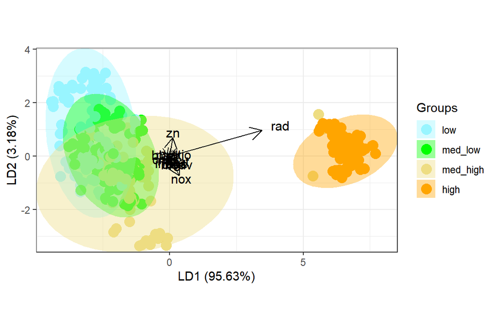

```r
cols <- c("cadetblue1","green","lightgoldenrod","orange")
ggord(lindis, tb_boston_st_train$crim, axes=c("1","2"), cols=cols )
```

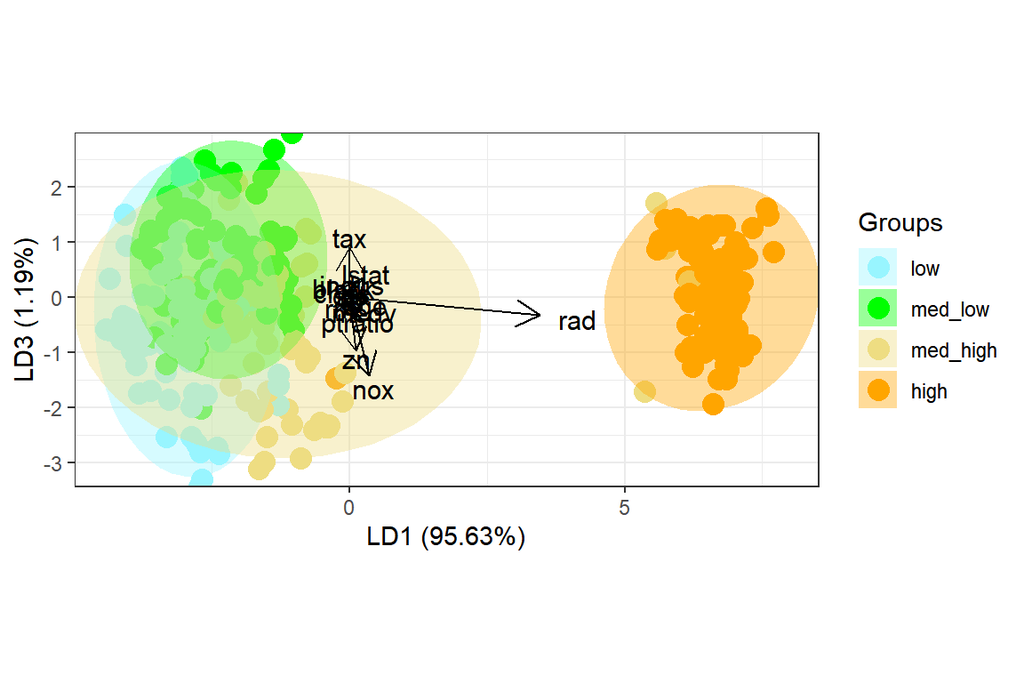

```r
ggord(lindis, tb_boston_st_train$crim, axes=c("1","3"), cols=cols )
```

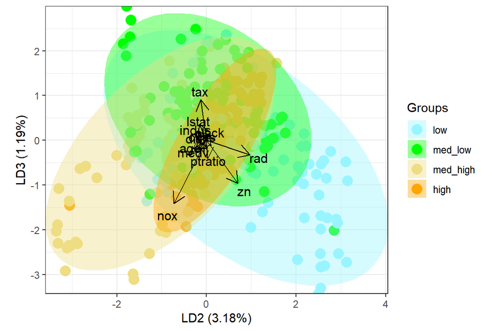

```r
ggord(lindis, tb_boston_st_train$crim, axes=c("2","3"), cols=cols )
```

In terms of studing the crime in the area, it seems like the firt linear dimension LD1 is the most interesting one, as it is the only one really separating the high-crime areas from the areas with lower crimes. It also seems like the variable “rad” is the one strongest associating with LD1, does a high access to highways associate with high crime rates?

Maybe living areas close to the highways are less desirable, and so high-resource residents live further away from highways, and that this demographic associates with lower crime.

## 6) Prediction

```r
# Making predictions
crim_predicted <- predict(lindis, newdata = tb_boston_st_test %>% select(-crim))

# Creating a cross tabulation
table(correct = tb_boston_st_test$crim, predicted = crim_predicted$class)
```

```
##           predicted
## correct    low med_low med_high high
##   low       20       8        0    0
##   med_low    2      18        4    0
##   med_high   0       3       16    2
##   high       0       0        0   28
```

Seems like our model got a few correct predicted (diagonal values). But what’s the percent correct guessed?

```r
# Create alternative cross tabulation
tb_boston_st_test %>%
  mutate(
    predicted = crim_predicted$class
  ) %>%
  group_by(crim) %>%
  summarise(n=n(), n_pred_correct=sum(crim==predicted), p_pred_correct = n_pred_correct/n*100)
```

```
## # A tibble: 4 x 4
##   crim         n n_pred_correct p_pred_correct
##   <fct>    <int>          <int>          <dbl>
## 1 low         28             20           71.4
## 2 med_low     24             18           75
## 3 med_high    21             16           76.2
## 4 high        28             28          100
```

## 7) Distances and clusters

```r
dist_eu = dist(tb_boston_st, method="euclidean")
summary(dist_eu)
```

```
##    Min. 1st Qu.  Median    Mean 3rd Qu.    Max.
##  0.1394  3.5267  4.9081  4.9394  6.2421 13.0045
```

The median euclidian distnace is 4.9, and the max distance is 13

Next, let’s try clustering our data. First, we’ll figure out what number of clusters are sensible to use. In the code below, we compare the total within-cluster sum of squares for different numbers of cluster. However, as an additional detail, I’ve done the same calculations 10 times over and then taken the mean for each choice of cluster number; This reduces the random variation in the graph and smoothens the curve a bit.

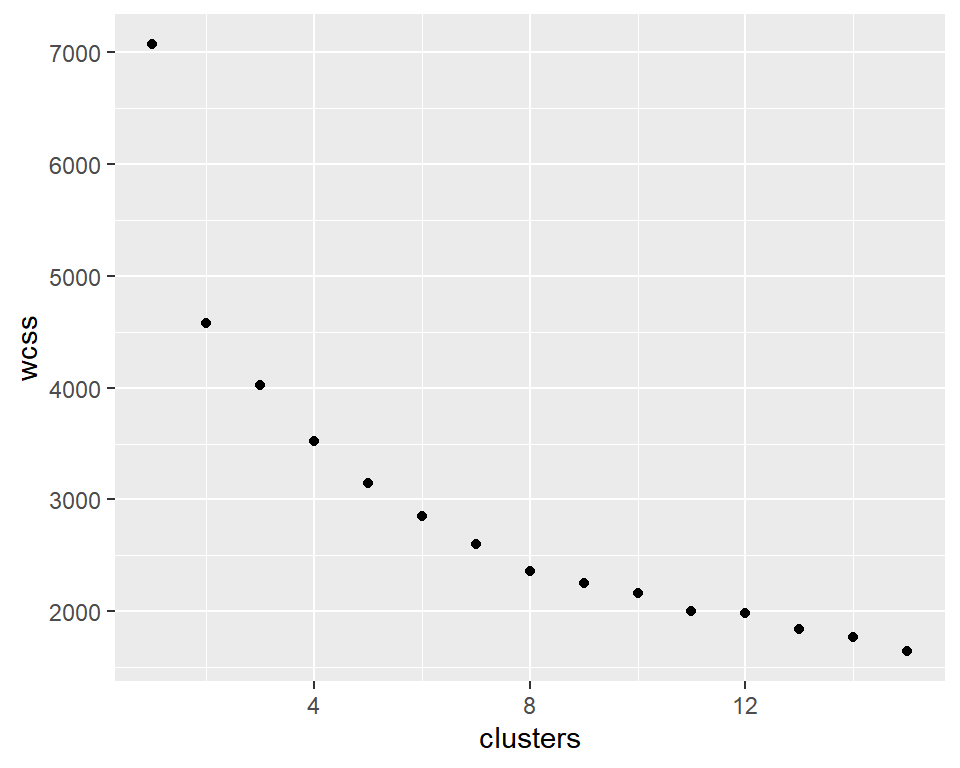

```r
v_clusters = rep(1:15,10)
v_wcss <- sapply(v_clusters, function(k){kmeans(tb_boston %>% mutate_all(~scale(.)[,1]), k)$tot.withinss})
tb_kmeans <- data.frame(clusters = v_clusters, wcss=v_wcss) %>%
  group_by(clusters) %>%
  summarise(wcss=mean(wcss))

ggplot(tb_kmeans)+aes(x=clusters,y=wcss)+geom_point()
```

Seems like our biggest fall in total within-cluster sum of squares is when going from 1 to 2 clusters; The following additions of clusters still improve the sum of squares, but not nearly as much.

Let’s group our data by two clusters and show these clusters on the original graphical summary:

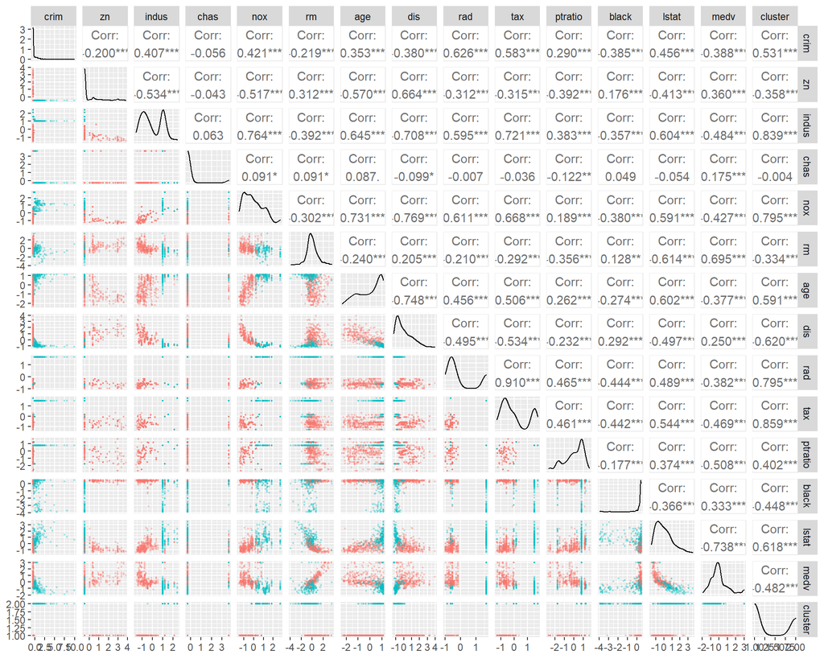

```r
kmeans = kmeans(tb_boston %>% mutate_all(~scale(.)[,1]), 2)

tb_boston_kmeans <- tb_boston %>%
  mutate_all(~scale(.)[,1]) %>%
  mutate(cluster=kmeans$cluster)

ggpairs(
  data = tb_boston_kmeans,
  lower = list(continuous = wrap("points", alpha = 0.3, size=0.3), mapping=aes(color=factor(cluster))),
)
```

Here we can see visually which points belong to the two clusters, blue and red. What do to the clusters associate with? It seems like Blue associates with… - Higher-than-low crime rates - Low amounts of residential land zoned for lots over 25,000 sq ft (few large properties?) - High amounts of industry - High concentrations of nitrogen oxides - Somewhat lower amounts of rooms pr dwelling - More older buildings - Closer distance to employment centres - Higher accesibility of highways - Higher tax rate (full-value property-tax rate) - Lower proportion of blacks - Higher proportion of lower-status residents - Lower value of homes

Thus, one way to interpret this, is that the areas in boston can be divided into two clusters; one “high-value” cluster with low crime rates, expensive homes, nice air quality, low amounts of industry and so on; and then one “low-value” cluster with higher crime rates, less expensive homes but lower air quality and higher amounts of industry.

## Bonus

Finally, lets try separating the dataset into 3 clusters, and then running a LDA analysis on it

```r
set.seed(123)
kmeans = kmeans(tb_boston %>% mutate_all(~scale(.)[,1]), 3)

tb_boston_kmeans_3 <- tb_boston %>%
  mutate_all(~scale(.)[,1]) %>%
  mutate(cluster=kmeans$cluster)

lindis_clustered <- MASS::lda(cluster~.,tb_boston_kmeans_3)

lindis_clustered
```

```
## Call:
## lda(cluster ~ ., data = tb_boston_kmeans_3)
##
## Prior probabilities of groups:
##         1         2         3
## 0.2806324 0.3992095 0.3201581
##
## Group means:
##         crim         zn        indus        chas         nox         rm
## 1  0.9693718 -0.4872402  1.074440092 -0.02279455  1.04197430 -0.4146077
## 2 -0.3549295 -0.4039269  0.009294842  0.11748284  0.01531993 -0.2547135
## 3 -0.4071299  0.9307491 -0.953383032 -0.12651054 -0.93243813  0.6810272
##          age        dis        rad        tax     ptratio      black
## 1  0.7666895 -0.8346743  1.5010821  1.4852884  0.73584205 -0.7605477
## 2  0.3096462 -0.2267757 -0.5759279 -0.4964651 -0.09219308  0.2473725
## 3 -1.0581385  1.0143978 -0.5976310 -0.6828704 -0.53004055  0.3582008
##         lstat       medv
## 1  0.85963373 -0.6874933
## 2  0.09168925 -0.1052456
## 3 -0.86783467  0.7338497
##
## Coefficients of linear discriminants:
##                 LD1         LD2
## crim     0.03654114  0.20373943
## zn      -0.08346821  0.34784463
## indus   -0.32262409 -0.12105014
## chas    -0.04761479 -0.13327215
## nox     -0.13026254  0.15610984
## rm       0.13267423  0.44058946
## age     -0.11936644 -0.84880847
## dis      0.23454618  0.58819732
## rad     -1.96894437  0.57933028
## tax     -1.10861600  0.53984421
## ptratio -0.13087741 -0.02004405
## black    0.15432491 -0.06106305
## lstat   -0.14002173  0.14786473
## medv     0.02559139  0.37307811
##
## Proportion of trace:
##    LD1    LD2
## 0.8999 0.1001
```

Here we can see that the linear discriminant analysis separataed our data into two dimensions, where LD1 is the most important one. The most important variables within LD1 seem to be rad (-1.96), tax (-1.11) and indus (-0.32).

Let’s have a look at this graphically:

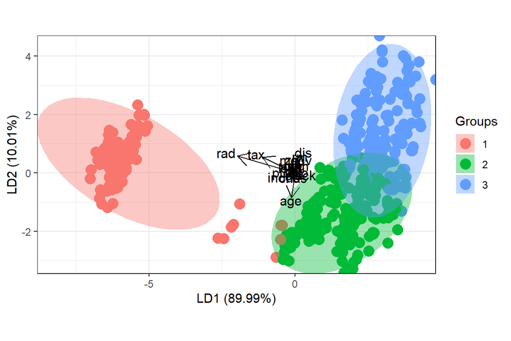

```r
ggord(lindis_clustered, factor(tb_boston_kmeans_3$cluster))
```

This shows us more or less the same. Especially cluster 1 seems to separate nicely in the LDA analysis, with taxation and and access to highways being the variables mostly separating these areas from the other ones.

# Chapter 5 HDI data and Principal component analysis.

## 1) Data overview

> 1: Show a graphical overview of the data and show summaries of the variables in the data. Describe and interpret the outputs, commenting on the distributions of the variables and the relationships between them. (0-3 points)

```r
library(tidyverse)
library(GGally)
library(ggfortify)
tb_human <- read_delim("data/data-human-v2.txt",)

# Note: Here, I'm using a version of the human dataset without countries as row names.


color_correlation <- function(data, mapping, method="p", use="pairwise", ...){
    # Function by user20650 on Stackoverflow (https://stackoverflow.com/a/53685979)
    # for ggpairs function, adding color by correlation
    # grab data
    x <- eval_data_col(data, mapping$x)
    y <- eval_data_col(data, mapping$y)

    # calculate correlation
    corr <- cor(x, y, method=method, use=use)

    # calculate colour based on correlation value
    # Here I have set a correlation of minus one to blue,
    # zero to white, and one to red
    # Change this to suit: possibly extend to add as an argument of `my_fn`
    colFn <- colorRampPalette(c("blue", "white", "red"), interpolate ='spline')
    fill <- colFn(100)[findInterval(corr, seq(-1, 1, length=100))]

    ggally_cor(data = data, mapping = mapping, ...) +
      theme_void() +
      theme(panel.background = element_rect(fill=fill))
  }


tb_human %>%
 select(-Country) %>%
 pivot_longer(everything()) %>%
 group_by(name) %>%
 summarise(mean=round(mean(value),2), sd=round(sd(value),2))
```

```
## # A tibble: 8 x 3
##   name          mean       sd
##   <chr>        <dbl>    <dbl>
## 1 Ado.Birth    47.2     41.1
## 2 Edu.Exp      13.2      2.84
## 3 Edu2.FM       0.85     0.24
## 4 GNI       17628.   18544.
## 5 Labo.FM       0.71     0.2
## 6 Life.Exp     71.6      8.33
## 7 Mat.Mor     149.     212.
## 8 Parli.F      20.9     11.5
```

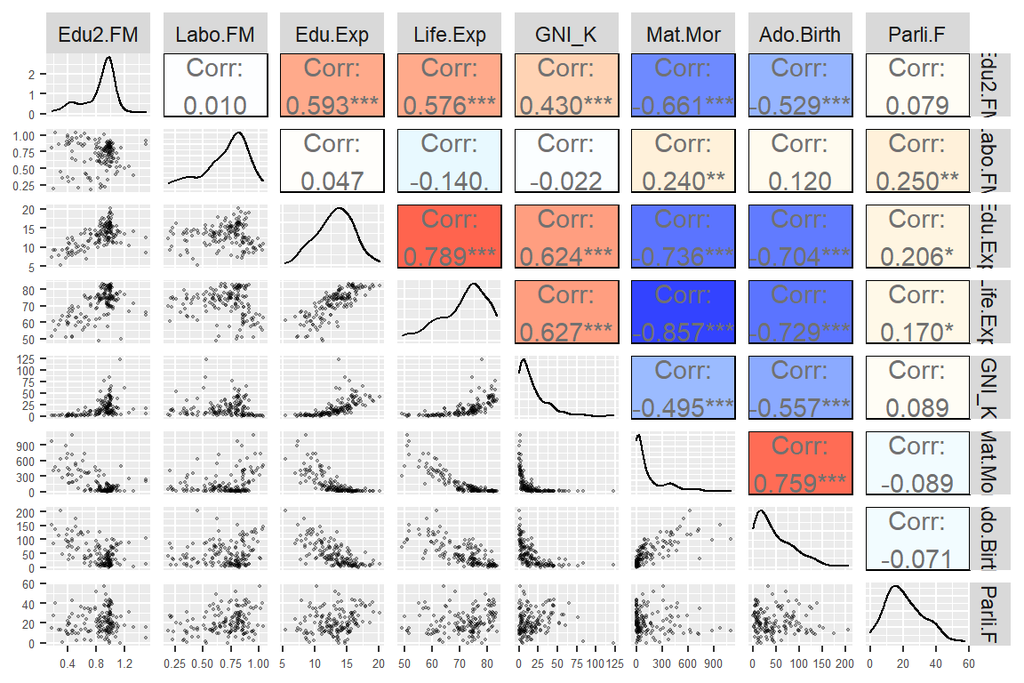

```r
ggpairs(
  # Adjusting GNI to be expressed in thousands, to make graph more easy to read
  data = tb_human %>% mutate(GNI = GNI / 1000) %>% rename(GNI_K=GNI) %>% select(-Country),
  # Coloring by correlation
  upper = list(continuous = color_correlation),
  lower = list(continuous = wrap("points", alpha = 0.3, size=0.3)),
) +
  theme(axis.text = element_text(size=5))
```

**Notable correlations:**

- There is a positive correlation between expected years of eduction, F/M ratio for higher education, life expectancy and GNI. People living in high-income countries have longer exptected educations, more women in higher education and longer life-expectancy.
- On the other hand, rates of maternal mortality and births among adolescents correlate negatively to these measures.
- Finally, the amount of females in parliament, and the share of females in the workforce don’t correlate strongly with any of these variables. The correaltions it does have, however, are somewhat counterintuitive; Countries with a high amount of females in the workforce also have a higher maternal mortality.

## 2) PCA

> 2: Perform principal component analysis (PCA) on the raw (non-standardized) human data. Show the variability captured by the principal components. Draw a biplot displaying the observations by the first two principal components (PC1 coordinate in x-axis, PC2 coordinate in y-axis), along with arrows representing the original variables. (0-2 points)

First, running the PCA analysis and printing out the principal components:

```r
# Running PCA
pca_human <- prcomp(tb_human %>% select(-Country))
pca_human
```

```
## Standard deviations (1, .., p=8):
## [1] 1.854416e+04 1.855219e+02 2.518701e+01 1.145441e+01 3.766241e+00
## [6] 1.565912e+00 1.912052e-01 1.591112e-01
##
## Rotation (n x k) = (8 x 8):
##                     PC1           PC2           PC3           PC4           PC5
## Edu2.FM   -5.607472e-06  0.0006713951 -3.412027e-05 -2.736326e-04 -0.0022935252
## Labo.FM    2.331945e-07 -0.0002819357  5.302884e-04 -4.692578e-03  0.0022190154
## Edu.Exp   -9.562910e-05  0.0075529759  1.427664e-02 -3.313505e-02  0.1431180282
## Life.Exp  -2.815823e-04  0.0283150248  1.294971e-02 -6.752684e-02  0.9865644425
## GNI       -9.999832e-01 -0.0057723054 -5.156742e-04  4.932889e-05 -0.0001135863
## Mat.Mor    5.655734e-03 -0.9916320120  1.260302e-01 -6.100534e-03  0.0266373214
## Ado.Birth  1.233961e-03 -0.1255502723 -9.918113e-01  5.301595e-03  0.0188618600
## Parli.F   -5.526460e-05  0.0032317269 -7.398331e-03 -9.971232e-01 -0.0716401914
##                     PC6           PC7           PC8
## Edu2.FM    2.180183e-02  6.998623e-01  7.139410e-01
## Labo.FM    3.264423e-02  7.132267e-01 -7.001533e-01
## Edu.Exp    9.882477e-01 -3.826887e-02  7.776451e-03
## Life.Exp  -1.453515e-01  5.380452e-03  2.281723e-03
## GNI       -2.711698e-05 -8.075191e-07 -1.176762e-06
## Mat.Mor    1.695203e-03  1.355518e-04  8.371934e-04
## Ado.Birth  1.273198e-02 -8.641234e-05 -1.707885e-04
## Parli.F   -2.309896e-02 -2.642548e-03  2.680113e-03
```

Let’s look at how much variation is explained by different components:

```r
# Displaying variability captured by different principal components
summary(pca_human)
```

```
## Importance of components:
##                              PC1      PC2   PC3   PC4   PC5   PC6    PC7    PC8
## Standard deviation     1.854e+04 185.5219 25.19 11.45 3.766 1.566 0.1912 0.1591
## Proportion of Variance 9.999e-01   0.0001  0.00  0.00 0.000 0.000 0.0000 0.0000
## Cumulative Proportion  9.999e-01   1.0000  1.00  1.00 1.000 1.000 1.0000 1.0000
```

Note how PC1 seems to capture most of the variance, and that GNI seems to be the most important value in PC1

Let’s draw the biplot:

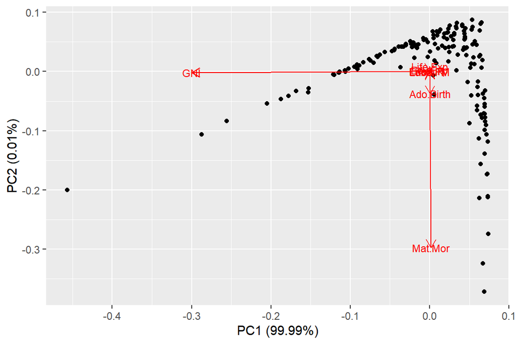

```r
autoplot(pca_human, data = tb_human, loadings.label = TRUE, loadings.label.size = 3)
```

PCA biplot of HDI data (unstandardized). The plot seems to indicate that most of the variation in our dataset can be captured by principal component 1, which is strongly associated with the gross national income par capita. Principal component 2 is far less importan (explains 0.01% of the variation); here maternal mortality rates is the most strongly associated variable.

Interesting; we’ll discuss more below.

## 3) PCA post standardizing

> 3: Standardize the variables in the human data and repeat the above analysis. Interpret the results of both analysis (with and without standardizing). Are the results different? Why or why not? Include captions (brief descriptions) in your plots where you describe the results by using not just your variable names, but the actual phenomena they relate to. (0-4 points)

```r
tb_human_st <-
  tb_human %>%
  mutate_at(vars(-"Country"),
    ~ scale(.)[,1]
    )

pca_human_st <- prcomp(tb_human_st %>% select(-Country))
pca_human_st
```

```
## Standard deviations (1, .., p=8):
## [1] 2.0708380 1.1397204 0.8750485 0.7788630 0.6619563 0.5363061 0.4589994
## [8] 0.3222406
##
## Rotation (n x k) = (8 x 8):
##                   PC1         PC2         PC3         PC4        PC5
## Edu2.FM   -0.35664370  0.03796058 -0.24223089  0.62678110 -0.5983585
## Labo.FM    0.05457785  0.72432726 -0.58428770  0.06199424  0.2625067
## Edu.Exp   -0.42766720  0.13940571 -0.07340270 -0.07020294  0.1659678
## Life.Exp  -0.44372240 -0.02530473  0.10991305 -0.05834819  0.1628935
## GNI       -0.35048295  0.05060876 -0.20168779 -0.72727675 -0.4950306
## Mat.Mor    0.43697098  0.14508727 -0.12522539 -0.25170614 -0.1800657
## Ado.Birth  0.41126010  0.07708468  0.01968243  0.04986763 -0.4672068
## Parli.F   -0.08438558  0.65136866  0.72506309  0.01396293 -0.1523699
##                   PC6         PC7         PC8
## Edu2.FM    0.17713316  0.05773644  0.16459453
## Labo.FM   -0.03500707 -0.22729927 -0.07304568
## Edu.Exp   -0.38606919  0.77962966 -0.05415984
## Life.Exp  -0.42242796 -0.43406432  0.62737008
## GNI        0.11120305 -0.13711838 -0.16961173
## Mat.Mor    0.17370039  0.35380306  0.72193946
## Ado.Birth -0.76056557 -0.06897064 -0.14335186
## Parli.F    0.13749772  0.00568387 -0.02306476
```

```r
summary(pca_human_st)
```

```
## Importance of components:
##                           PC1    PC2     PC3     PC4     PC5     PC6     PC7
## Standard deviation     2.0708 1.1397 0.87505 0.77886 0.66196 0.53631 0.45900
## Proportion of Variance 0.5361 0.1624 0.09571 0.07583 0.05477 0.03595 0.02634
## Cumulative Proportion  0.5361 0.6984 0.79413 0.86996 0.92473 0.96069 0.98702
##                            PC8
## Standard deviation     0.32224
## Proportion of Variance 0.01298
## Cumulative Proportion  1.00000
```

Now this changes things! PC1 is still the most important, but not by far as much as previously.

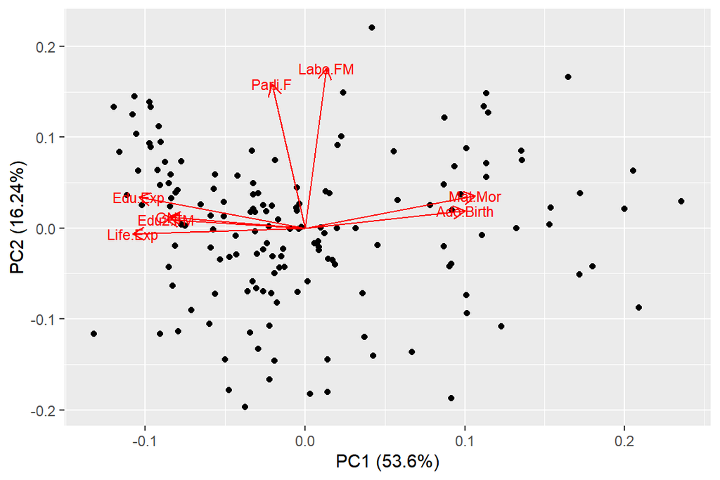

```r
autoplot(pca_human_st, x=1,y=2, data = tb_human, loadings.label = TRUE, loadings.label.size = 3)
```

biplot of HDI data (standarized). Here, the data is separating into two axes: PC1 (explains the most variation at 53.6%) relates to variables related mainly to economic- and health care development (such as life expectancy, gross national income per capita, expected number of years in eduction, maternal mortality rates, adolescent birth rates, but also proportion in females in higher education). The other (PC2) explains less variation (16.24%) axis relates female participation in politics and in the workforce.

The results are obviously very differently. The reason for this is that the variables are now expressed in relation to their own variation, not their absolute size. Previously, GNI was the most important variable partly because it also held the largest values and the most variation (same goes for maternal mortality), after adjusting it so that it is expressed in standard deviations, it is analysed on the same basis as the other variables. Thus, after standardizing, we’re analysing the dataset based on the **relative** variation in the selected variables, not the absolute variation.

## 4) Interpretations

> 4: Give your personal interpretations of the first two principal component dimensions based on the biplot drawn after PCA on the standardized human data. (0-2 points)

We can see that the data is divided on mainly two axes: PC1 seem to include variables related to overall economic and health-care development such as GNI, life expectancy, maternal mortality rates, and adolescent birth rates. The other axis seems to contain values related to female participation in the workforce and in politics. It is interesting to note that these two axis separate quite strongly, almost as if economic development and gender equality in the workforce and in politics is separated. On that note, it is also interesting that gender equality in education is one the same axis as economic development (PC1), but not on the “gender-participation” axis (PC2)

## 5) Tea data

> 5: The tea data comes from the FactoMineR package and it is measured with a questionnaire on tea: 300 individuals were asked how they drink tea (18 questions) and what are their product’s perception (12 questions). In addition, some personal details were asked (4 questions). Explore the data briefly: look at the structure and the dimensions of the data. Use View(tea) to browse its contents, and visualize the data. Use Multiple Correspondence Analysis (MCA) on the tea data (or on just certain columns of the data, it is up to you!). Interpret the results of the MCA and draw at least the variable biplot of the analysis. You can also explore other plotting options for MCA. Comment on the output of the plots. (0-4 points)

```r
library(FactoMineR)
tb_tea <- read.csv("https://raw.githubusercontent.com/KimmoVehkalahti/Helsinki-Open-Data-Science/master/datasets/tea.csv", stringsAsFactors = TRUE)
```

The dataset countains 300 observations (people), with columns representing how they answered various questions. Almost all variables are factors with fairly few levels, often only two. Age is the only variable expressed as a number. The datasets seems to contain data about how people drink their tea, how often, and then with some question about personal details, and about how they feel about tea drinking.

For the multiple correspondent analysis, we’re only going to look at the first 19 columns as they seem to be the most important ones for traits related to tea drinking in itself.

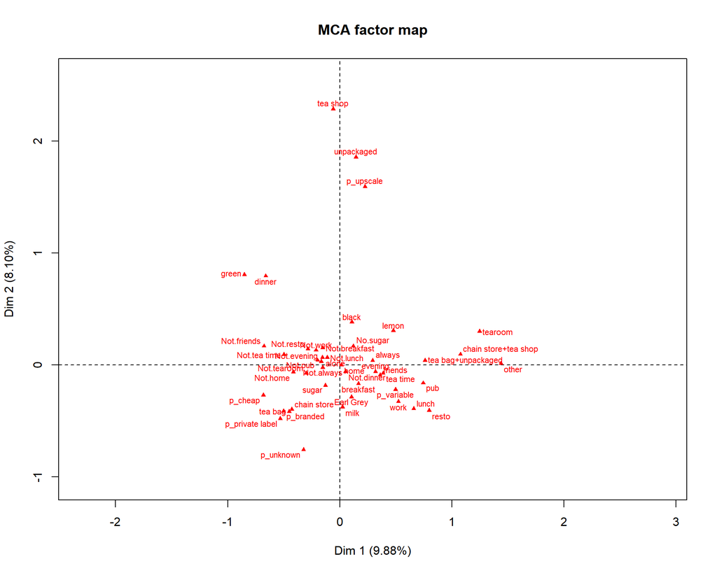

```r
mca_tea<-  FactoMineR::MCA(tb_tea, quanti.sup=19, quali.sup=c(20:36), graph=FALSE)


# visualize MCA
plot(mca_tea, invisible=c("ind","quali.sup","quanti.sup"), graph.type = "classic",cex=0.7)
```

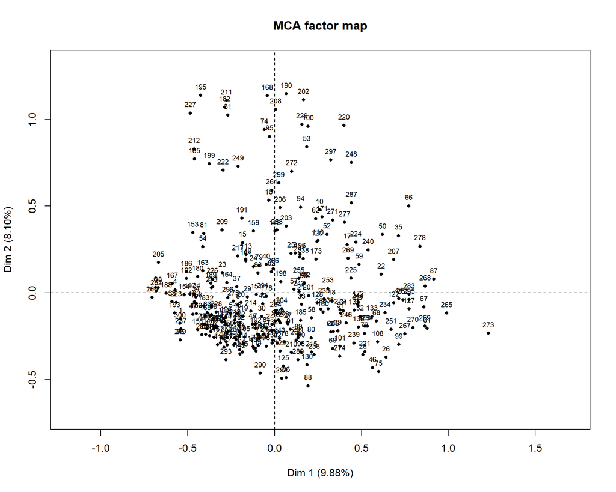

```r
plot(mca_tea, invisible=c("var","quali.sup","quanti.sup"), graph.type = "classic",cex=0.7)
```

The *first* plot shows us how different answers relate to the two main principal component, while the *second* plot shows us where different individuals fall on these two dimensions. We can see that the populations is fairly homogeneous, there aren’t any obvious groupings among the respondents. On the first graph, we can try to make sense of what the two dimensions associate with. On the **upper extreme** of Dim 1 we see answers such as “tearoom”, “chainstore+teashop”, “tea bag+unpackaged”, “always”, “pub”, “lunch”, and “work”, while on the **lower extreme** we have answers like “not.tea time”, “not work”, “p_cheap”, “not.home”, “not.tearoom” etc. One way to interpret this is that dimension one separates frequent tea drinkers from those drinking tea rarely. The second dimension could relate to buying patterns of tea. Those on the higher end of Dim 2 like to buy more expensive, unpackaged teas from specialiced tea shops, while those on the lower end buy their teas from chain stores, use tea bags, have milk in their tea, and drink Earl Grey.